# MSCBD-DMAT - Asignment 1 - Nithin Umamahesh

## Optimal eps value

The method proposed here consists of computing the he k-nearest neighbor distances in a matrix of points.

The idea is to calculate, the average of the distances of every point to its k nearest neighbors. The value of k will be specified by the user and corresponds to MinPts.

Next, these k-distances are plotted in an ascending order. The aim is to determine the âkneeâ, which corresponds to the optimal eps parameter.

A knee corresponds to a threshold where a sharp change occurs along the k-distance curve.

The function kNNdistplot() [in dbscan package] can be used to draw the k-distance plot:

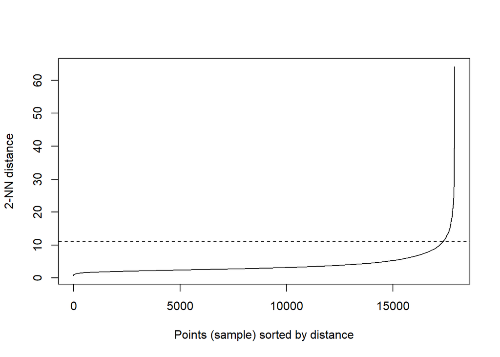

```r
# We find the optimal epsilon value for forming two clusters
dbscan::kNNdistplot(pulsar_stars, k =  2)
abline(h = 11, lty = 2) # draw a line at this eps value on the plot
```

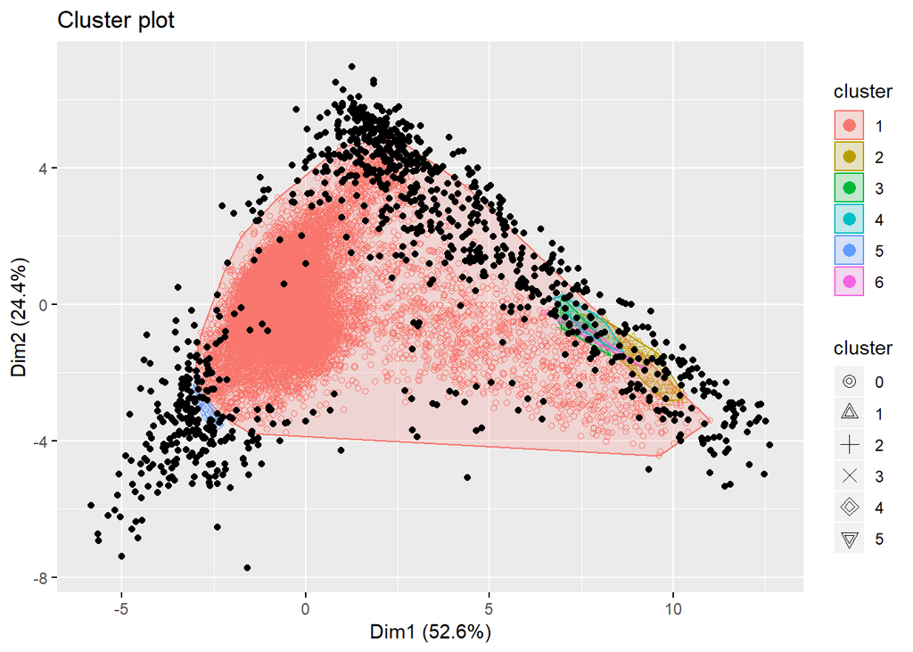

```r
eps_value = 11 # set a value for eps based on the value suggested by the plot
MinPts_value = 10 # vary the MinPts_value until suitable clusters are generated
db <- fpc::dbscan(pulsar_stars, eps = eps_value, MinPts = MinPts_value) # run the DBSCAN algorithm with the appropiate values
#plot(db, d1, main = paste("eps:",eps_value,", MinPts:",MinPts_value, sep = " "), frame = FALSE) # Plot DBSCAN results
fviz_cluster(db,pulsar_stars,geom = "point")
```

# From the above snapshot of the graph we can see that there are 6 clusters formed instead of two. This is because of the very low minimum points required to form a core point.

# Experiment 2:

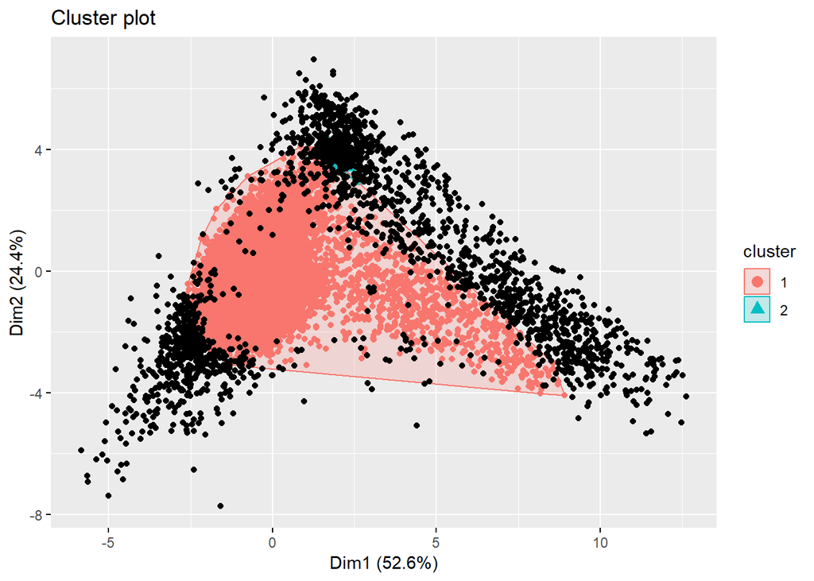

```r
eps_value = 11 # set a value for eps based on the value suggested by the plot
MinPts_value = 25 # vary the MinPts_value until suitable clusters are generated
db <- fpc::dbscan(pulsar_stars, eps = eps_value, MinPts = MinPts_value) # run the DBSCAN algorithm with the appropiate values
fviz_cluster(db,pulsar_stars,geom = "point")
```

# From the above plot we can see that two clusters have been formed at min pts = 25

# Eperiment 3:

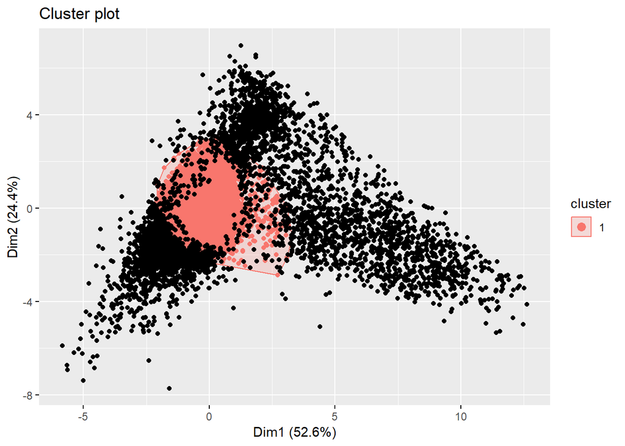

```r
eps_value = 11 # set a value for eps based on the value suggested by the plot
MinPts_value = 100 # vary the MinPts_value until suitable clusters are generated
db <- fpc::dbscan(pulsar_stars, eps = eps_value, MinPts = MinPts_value) # run the DBSCAN algorithm with the appropiate values
fviz_cluster(db,pulsar_stars,geom = "point")
```

# In the above graph only one cluster has been formed. This is because of the large minimum points required to form the core point.

# Eperiment 4:

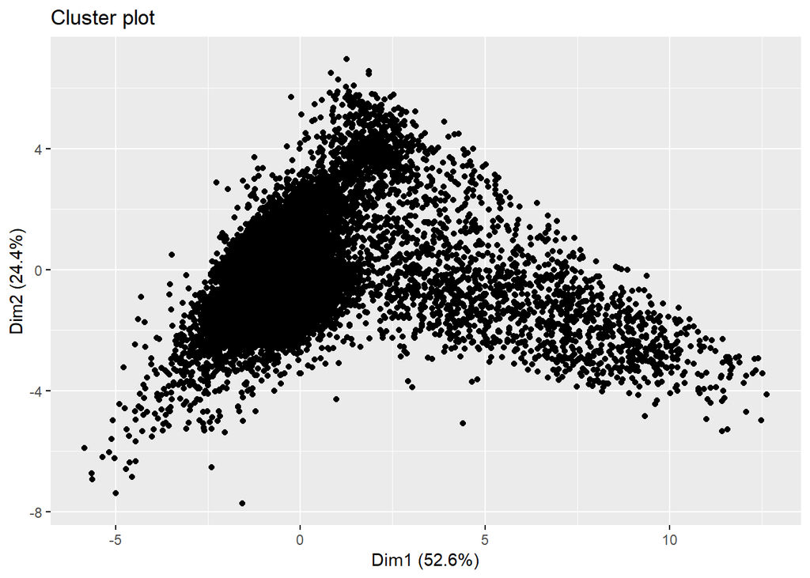

```r
eps_value = 11 # set a value for eps based on the value suggested by the plot
MinPts_value = 1000 # vary the MinPts_value until suitable clusters are generated
db <- fpc::dbscan(pulsar_stars, eps = eps_value, MinPts = MinPts_value) # run the DBSCAN algorithm with the appropiate values
fviz_cluster(db,pulsar_stars,geom = "point")
```

# From the above figure we can see that no cluster has been formed due to the very large number of points required to form a core point. Hence all the points are considered as noise in the above graph.

# Additional Information

## Instructions on how to edit this RMarkdown document

A cheatsheet for RMarkdown can be found [here] (https://rstudio.com/wp-content/uploads/2015/02/rmarkdown-cheatsheet.pdf)

## Helpful Links

- How to read a CSV file http://www.cyclismo.org/tutorial/R/input.html#read